# Brauchle_HW6

Natascha Brauchle

March 26, 2019

6a.  
The degree of the polynomial chosen by cross-validation is 4, which actually matches the results of ANOVA. The output from ANOVA shows that there are marginal improvements in error when increasing the degree of the polynomial past 4, so we choose 4 as our degree.

The polynomial fits the data decently well, but does not capture the points hovering above the main curve.

```r
wage <- Wage

set.seed(1)
cv.error=rep(1,10)
for (i in 1:10){
  glm.fit=glm(wage ~ poly(age,i), data=wage)
  cv.error[i]=cv.glm(wage, glm.fit, K=10)$delta [1]
  }
cv.error
```

```
##  [1] 1675.837 1601.012 1598.801 1594.217 1594.625 1594.888 1595.500
##  [8] 1595.436 1596.335 1595.835
```

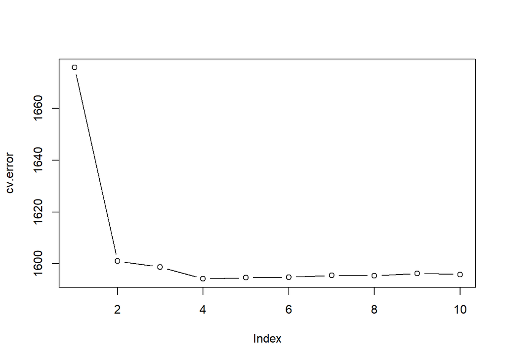

```r
plot(cv.error, type = 'b')
```

```r
# anova
fit1 <- glm(wage ~ poly(age, 1), data = wage)
fit2 <- glm(wage ~ poly(age, 2), data = wage)
fit3 <- glm(wage ~ poly(age, 3), data = wage)
fit4 <- glm(wage ~ poly(age, 4), data = wage)
fit5 <- glm(wage ~ poly(age, 5), data = wage)
fit6 <- glm(wage ~ poly(age, 6), data = wage)
fit7 <- glm(wage ~ poly(age, 7), data = wage)
fit8 <- glm(wage ~ poly(age, 8), data = wage)
fit9 <- glm(wage ~ poly(age, 9), data = wage)
fit10 <- glm(wage ~ poly(age, 10), data = wage)
anova(fit1, fit2, fit3, fit4, fit5, fit6, fit7, fit8, fit9, fit10)
```

```
## Analysis of Deviance Table
##
## Model  1: wage ~ poly(age, 1)
## Model  2: wage ~ poly(age, 2)
## Model  3: wage ~ poly(age, 3)
## Model  4: wage ~ poly(age, 4)
## Model  5: wage ~ poly(age, 5)
## Model  6: wage ~ poly(age, 6)
## Model  7: wage ~ poly(age, 7)
## Model  8: wage ~ poly(age, 8)
## Model  9: wage ~ poly(age, 9)
## Model 10: wage ~ poly(age, 10)
##    Resid. Df Resid. Dev Df Deviance
## 1       2998    5022216
## 2       2997    4793430  1   228786
## 3       2996    4777674  1    15756
## 4       2995    4771604  1     6070
## 5       2994    4770322  1     1283
## 6       2993    4766389  1     3932
## 7       2992    4763834  1     2555
## 8       2991    4763707  1      127
## 9       2990    4756703  1     7004
## 10      2989    4756701  1        3
```

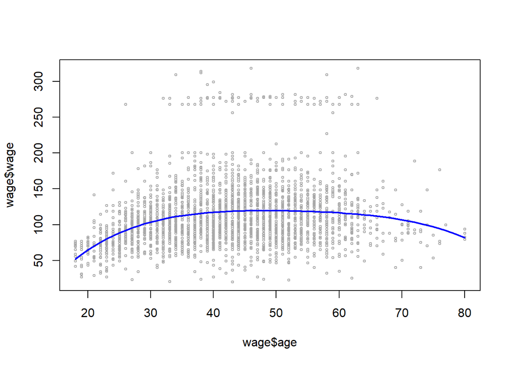

```r
fit = lm(wage ~ poly(age, 4), data = wage)
agelims = range(wage$age)
age.grid = seq(from = agelims[1], to = agelims[2])
preds = predict(fit, newdata =list(age = age.grid),se=TRUE)
plot(wage$age, wage$wage, xlim=agelims, cex = .5, col="darkgrey ")
lines(age.grid, preds$fit, lwd=2, col="blue")
```

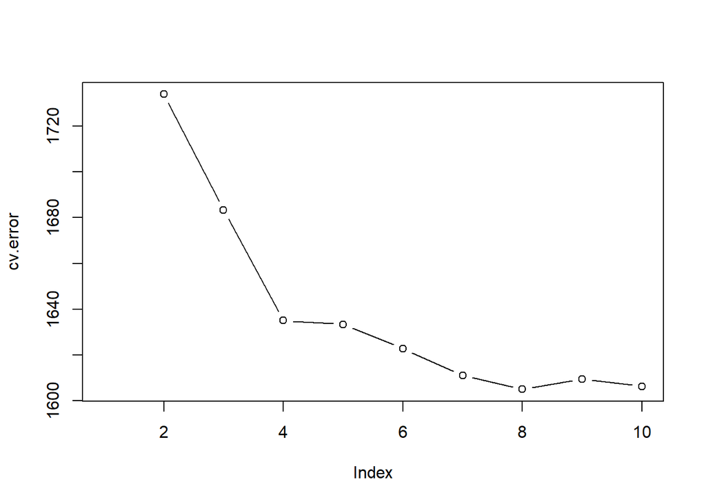

```r
cv.error = rep(NA, 10)

for (i in 2:10){
  wage$age.cut <- cut(wage$age, i)
  fit <- glm(wage ~ age.cut, data=wage)
  cv.error[i] <- cv.glm(wage, fit, K=10)$delta[1]
  }
plot(cv.error, type = 'b')
```